# Basic principles in Biostatistics: *likelihood* and statistical thinking

Boris Hejblum

September 10<sup>th</sup>, 2019

[figure not shown]

# 1 Motivational example

## 1.1 Birth weight study

Study on risks factor for low birth weights from Baystate medical center in Springfield (MA, USA) during 1986 [Hosmer & Lemeshow (1989), *Applied Logistic Regression*]

- `low`: low birth weight indicator coded as: `1` (low birth weight, i.e. $\leq 2.5kg$) and `0` (normal birth weight)
- `age`: mother’s age (in years) at the time of birth
- `lwt`: mother’s weight (in pounds) at the time of the last menstrual period
- `race`: mother’s race coded as: `1` (white), `2` (black) and `3` (other)
- `smoke`: mother’s smoking status coded as `1` (smoker) and `0` (non-smoker)
- `ptl`: number of previous premature labours
- `ht`: hypertension history indicator coded as: `1`(yes) and `0` (no)
- `ui`: uterine irritability indicator coded as: `1` (yes) and `0` (no)
- `ftv`: number of physician visits during the first trimester
- `bwt`: infant’s birth weight (in grams)

# 2 `R` primer

## 2.1 `R` 101 for M2 PHDS

1. launch `Rstudio`
2. open a new `.Rmd` file from the default template
3. compile it with the `"Knit"` button
4. discuss with your neighbor to understand each part of the script

## 2.2 Importing data

```r
  bw_data <- read.delim("birthweight_data.txt")
```

5. briefly describe the data (use nice table outputs in `Rmarkdown` and `ggplot2` graphics)

```r
library(knitr)
bw_data$smoke <- as.factor(bw_data$smoke) # tell R that smoke is a binary factor and not a continuous variable (the default)
knitr::kable(bw_data[1:5,])
```

| low | age | lwt | race | smoke | ptl | ht | ui | ftv | bwt |
| --- | --- | --- | --- | --- | --- | --- | --- | --- | --- |
| 0 | 19 | 182 | 2 | 0 | 0 | 0 | 1 | 0 | 2523 |
| 0 | 33 | 155 | 3 | 0 | 0 | 0 | 0 | 3 | 2551 |
| 0 | 20 | 105 | 1 | 1 | 0 | 0 | 0 | 1 | 2557 |
| 0 | 21 | 108 | 1 | 1 | 0 | 0 | 1 | 2 | 2594 |
| 0 | 18 | 107 | 1 | 1 | 0 | 0 | 1 | 0 | 2600 |

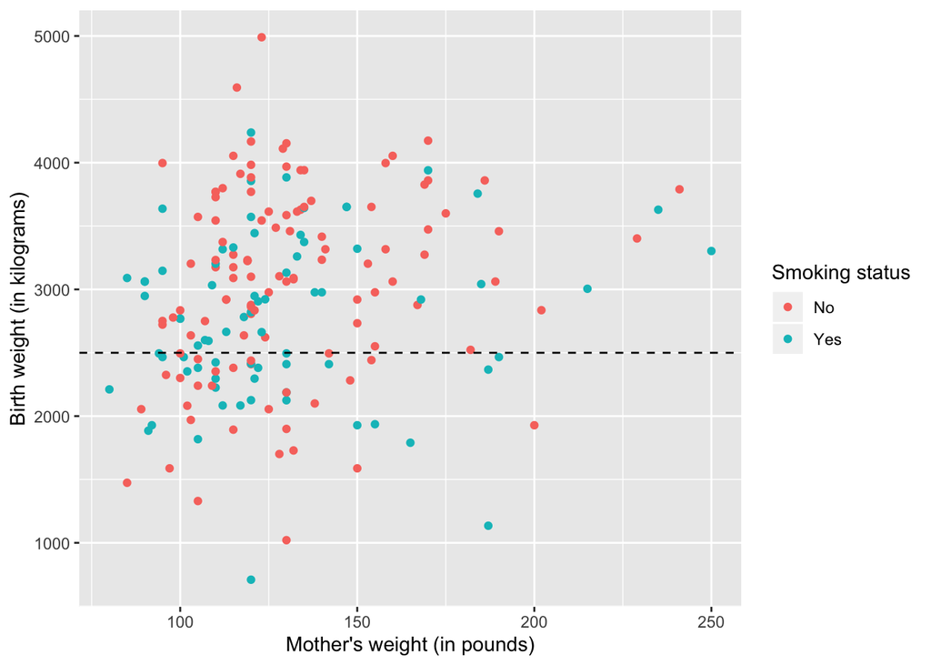

```r
library(ggplot2)
ggplot(bw_data) +
  geom_point(aes(y=bwt, x=lwt, color=smoke)) +
  geom_hline(aes(yintercept=2500), linetype=2) +
  xlab("Mother's weight (in pounds)") +
  ylab("Birth weight (in kilograms)") +
  scale_color_discrete("Smoking status", labels=c("No", "Yes"))
```

## 2.3 R basics

- program a function that add the logarithm of two numbers
- use `browser()` to debug your function when evaluating at negative arguments

```r
mylog <- function(a, b){
  #browser()
  ans <- log(a) + log(b)
  return(ans)
}
mylog(a = 1, b = 1)
```

```
## [1] 0
```

```r
mylog(a = 1, b = -1)
```

```
## [1] NaN
```

# 3 Statistical modeling

## 3.1 Why do we do (bio)statistics ?

**Statistics:** summarizing information from experimental observations and quantifying the associated uncertainty

> *Always start with the research/scientific question !*

## 3.2 How do we do (bio)statistics

- *ideally* we would start from our scientific question, figure out what data we need to answer the question
- *usually* the question is not very clear & the data have already been collected

**Statistical Inference**: we use a *simple* **Generative Probabilistic model** that could have generated the observations (Machine Learning sometimes reject this paradigm – cf. L. Breiman)

## 3.3 The likelihood

The **likelihood** is a fundamental building block of Biostatistics:

- its maximization yields estimators that have good asymptocic (when $n$ the number of observations increases indefinitely) properties – **no bias** and **smallest variance**,
- it also allows to perform significance testing of model parameters in many settings.

## 3.4 likelihood interpretation

The **likelihood function** quantifies how *likely* it is that a given (set of) observation(s) has been generated by our **hypothesized Generative Probabilistic model**.

The **likelihood function** is equal to the *model joint probability distribution* computed for the observations, and thus only a function of the *model parameters*.

## 3.5 Maximum Likelihood Estimator (**MLE**)

The idea of the MLE is to to optimize the likelihood function given the observations, by **finding the model parameters** that would give these observations the highest probability of being generated under the model.

> *seems like a reasonable and intuitive idea !*

## 3.6 Bayesian statistics

Reverend **Thomas Bayes** proposed an alternative framework for statistical inference (actually before the “frequentist” method). It also relies on a probabilistic model through the *likelihood* function, but has different philosophical grounds than the frequentist.

*To be continued…*

# 4 Computational statistics

Computational statistics have become essential in modern statistics, with always bigger data, and always more sophisticated approaches.

## 4.1 Maximizing the likelihood

Maximizing the likelihood can easily be done analytically for simple linear models.

*However*: non-linear likelihoods are hard (sometimes impossible) to optimize analytically !

$\Rightarrow$ **numerical optimization**

## 4.2 Newton-Raphson optimizer

An algorithm to find values for which a function is zero.

Applied to the **derivative** of the **likelihood function**, this will identify the MLE  
*given that the log-likelihood is a concave function*

## 4.3 Why always use the $log$ ?

Generally, we maximize the *log*-likelihood instead of the likelihood.

- same thing ($\log$ is a monotonically increasing function)
- **products** $\prod_{i=1}^n$ (e.g. likelihoods) become **sums** $\sum_{i=1}^n$  
  sums are easier to compute & easier to derivate
- more precision for small positives numbers (e.g. small probabilities)

## 4.4 $log-exponential$ trick

This is not taught often but it can come very handy if you are writing your own statistical/optimisation program:

$$\log \sum_{i=1}^n e^{x_i} = c + \log \sum_{i=1}^n e^{x_i-c}$$

*Disclaimer: not useful today*

## 4.5 Newton-Raphson optimizer intuition

1. start from an initial point $x_0$
2. tangential linear approximation of $f$ in $f(x_0)$
3. get the next point $x_1$ as the solution  
   …
14. Repeat until $x_{n+1}\approx x_n$

About the linear approximation at the $n + 1$ step: - goes through $f(x_n)$ - has slope $f'(x_n)$

So it has the following equation: $y= f'(x_n)(x-x_n) + f(x_n)$. Thus we find $x_{n+1}$ by setting $y=0$, which gives us $x_{n+1} = x_n -\frac{f(x_n)}{f'(x_n)}$

## 4.6 Newton-Raphson optimizer example

```r
#install.packages("animation")
library("animation")
newton.method(FUN = function(x) (x - 2)^2 - 1, init = 9.5,
              rg = c(-1, 10), tol = 0.001, interact = FALSE,
              col.lp = c("orange", "red3", "dodgerblue1"),
              lwd=1.5)
```

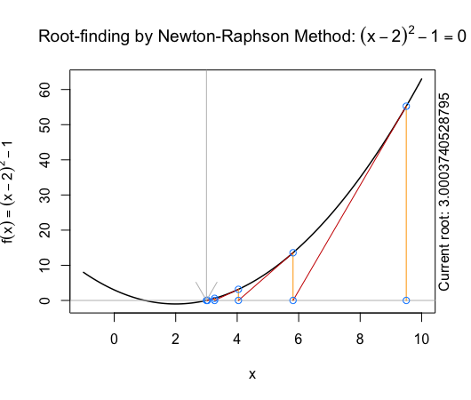

# 5 Practicals

## 5.1 *What is the prevalence of low birth weights in our data ?*

1. propose a generative probabilistic model

> We assume that the birth weight of each infant follows an independent Bernoulli distribution with the same probability parameter $\pi$:
> $$y_i\overset{iid}{\sim} Bernoulli(\pi)$$
> where $y_i$ is either $1$ if a low birth weight is observed for the $i$<sup>th</sup> baby, and $0$ otherwise.
2. define the parameter of interest

> $\pi$ is our parameter of interest and represents the probability of low birth weight (i.e. the prevalence).
3. Write down the log-likelihood and its the first derivative (by hand)

> $L(\pi | y_1, \dots, y_n) = \prod_{i=1}^n \pi^{y_i} (1-\pi)^{(1-y_i)}$ $\ell(\pi | y_1, \dots, y_n) = \sum_{i=1}^n y_ilog(\pi) + (1-y_i)log(1-\pi)$ $\ell'(\pi | y_1, \dots, y_n) = \sum_{i=1}^n \dfrac{y_i}{\pi} - \dfrac{1-y_i}{1-\pi}$
4. Show that the maximum value (that nullify the derivative) of this likelihood is for $\displaystyle\widehat{\pi}_{MLE} = \dfrac{1}{n}\sum_{i=1}^ny_i$

> $\displaystyle\ell'(\widehat{\pi}_{MLE} | y_1, \dots, y_n) = 0$  
> $\displaystyle\Leftrightarrow \sum_{i=1}^n \dfrac{y_i}{\widehat{\pi}_{MLE}} = \sum_{i=1}^n \dfrac{1-y_i}{1-\widehat{\pi}_{MLE}}$  
> $\displaystyle\Leftrightarrow \dfrac{1}{\widehat{\pi}_{MLE}} \sum_{i=1}^n y_i = \dfrac{1}{1-\widehat{\pi}_{MLE}}\sum_{i=1}^n (1-y_i)$  
> $\displaystyle\Leftrightarrow \dfrac{1}{\widehat{\pi}_{MLE}} \sum_{i=1}^n y_i = \dfrac{n - \sum_{i=1}^n y_i}{1-\widehat{\pi}_{MLE}}$  
> $\displaystyle\Leftrightarrow \sum_{i=1}^n y_i - \widehat{\pi}_{MLE} \sum_{i=1}^n y_i = n\widehat{\pi}_{MLE} - \widehat{\pi}_{MLE}\sum_{i=1}^n y_i$  
> $\displaystyle\Leftrightarrow \sum_{i=1}^n y_i = n\widehat{\pi}_{MLE}$

```r
mean(bw_data$low)
```

```
## [1] 0.3121693
```

## 5.2 Brute force numerical optimization

Now let’s use `R` to program a Newton-Raphson algorithm to maximise this likelihood numerically

1. write an `R` function that computes either the likelihood or the log-likelihood for a probabiliyt `p`, with two additional arguments: i) `obs` the vector of observations (that is `bw_data$low` by default) and ii) `log` a logical (that is `FALSE` by default)

```r
likelihood <- function(p, obs = bw_data$low, log=FALSE){

  n <- length(obs) #189

  res <- 1 # initial likelihood value
  res_log <- 0 # initial log-likelihood value

  for(i in 1:n){ # loop over all observation
    res <- res*p^obs[i]*(1-p)^(1-obs[i])
    res_log <- res_log + obs[i]*log(p) +(1-obs[i])*log(1-p)
  }

  if(log){
    return(res_log)
  }else{
    return(res)
  }
}
```

2. Write two `R` functions of `p` that compute the first and the second derivatives of the log-likelihood respectivelly (each with `obs=bw_data$low` as an additional argument)

```r
first_deriv_loglik <- function(p, obs = bw_data$low){
  n <- length(obs) #189
  res <- 0 # initial derivative value
  for(i in 1:n){
    res <- res + obs[i]/p - (1-obs[i])/(1-p)
  }
  return(res)
}

second_deriv_loglik <- function(p, obs = bw_data$low){
  n <- length(obs) #189
  res <- 0 # initial derivative value
  for(i in 1:n){
    res <- res - obs[i]/p^2 - (1-obs[i])/(1-p)^2
  }
  return(res)
}
```

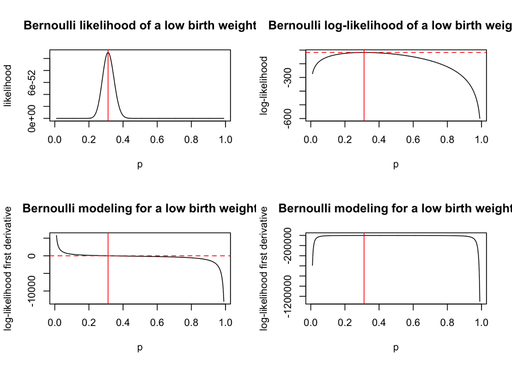

```r
par(mfrow = c(2,2)) # splitting the plot window into 4 subpanels
xvalues <- seq(from = 0.01, to = 0.99, by = 0.001)
plot(x = xvalues, y = likelihood(xvalues),
     type="l",
     ylab = "likelihood", xlab="p",
     main = "Bernoulli likelihood of a low birth weight")
abline(v=mean(bw_data$low), col="red")

plot(x = xvalues, y = likelihood(xvalues, log = TRUE),
     type="l",
     ylab = "log-likelihood", xlab="p",
     main = "Bernoulli log-likelihood of a low birth weight")
abline(v=mean(bw_data$low), col="red")
abline(h=likelihood(mean(bw_data$low), log=TRUE), col="red", lty=2)
plot(x = xvalues, y = first_deriv_loglik(xvalues),
     type="l",
     ylab = "log-likelihood first derivative", xlab="p",
     main = "Bernoulli modeling for a low birth weight")
abline(v=mean(bw_data$low), col="red")
abline(h=0, col="red", lty=2)
plot(x = xvalues, y = second_deriv_loglik(xvalues),
     type="l",
     ylab = "log-likelihood first derivative", xlab="p",
     main = "Bernoulli modeling for a low birth weight"
)
abline(v=mean(bw_data$low), col="red")
```

4. write a Newton-Raphson function with 5 arguments (the first deriative of the function to maximize, its second derivative, the initial starting point, the tolerance, the maximum number of iterations)

```r
newton_raphson <- function(f, fprime, init, tol=0.001, itermax=20, ...) {

  # initialization ----
    x_new <- init
    diff <- tol + 1  # ensure that the initialization is entering the while loop
    iter <- 0

  # updates ----
    while (diff > tol & iter < itermax) {
      # as long as diff is greater than the required precision AND the maximum number of iteration has not been reached
        iter <- iter + 1
        x_current <- x_new # store the current value
        x_new <- x_current - f(x_current, ...)/fprime(x_current, ...) #update to the new value
        diff <- abs(x_new - x_current) #compute the difference to assess convergence
        #diff <- abs(f(x_new) - f(x_current)) # a different convergence criterion
        cat(iter, " x_new:", x_new, " diff:", diff, "\n") #print the current step
    }

    if(iter == itermax){
      warning("Maximum number of iteration reached")
      # throw a warning if the maximum number of iteration is reached
    }

    return(x_new)
}
```

5. use all three functions to compute the MLE of the low birthweight prevalence

```r
pi_opt <- newton_raphson(f = first_deriv_loglik, fprime = second_deriv_loglik,
                         init = 0.7, tol=0.01)
```

```
## 1  x_new: 0.4769454  diff: 0.2230546
## 2  x_new: 0.3069933  diff: 0.169952
## 3  x_new: 0.3121212  diff: 0.005127827
```

```r
mean(bw_data$low)
```

```
## [1] 0.3121693
```

## 5.3 Robustness and statistical inference

1. Try several initial values, different tolerance, and experiment with different stopping rules – i.e. convergence criterion – (you can combine them). Compare the results. Does it always work ?

```r
newton_raphson(f = first_deriv_loglik, fprime = second_deriv_loglik,
                         init = 0.01, tol=0.01)
```

```
## 1  x_new: 0.01977524  diff: 0.009775238
```

```
## [1] 0.01977524
```

```r
newton_raphson(f = first_deriv_loglik, fprime = second_deriv_loglik,
                         init = 0.01, tol=0.0001)
```

```
## 1  x_new: 0.01977524  diff: 0.009775238
## 2  x_new: 0.0386545  diff: 0.01887927
## 3  x_new: 0.07375934  diff: 0.03510483
## 4  x_new: 0.1337386  diff: 0.05997927
## 5  x_new: 0.2175799  diff: 0.08384125
## 6  x_new: 0.2895745  diff: 0.0719946
## 7  x_new: 0.311171  diff: 0.0215966
## 8  x_new: 0.3121676  diff: 0.0009965095
## 9  x_new: 0.3121693  diff: 1.752721e-06
```

```
## [1] 0.3121693
```

2. Considering the null hypothesis $H_0: \pi=0.5$, compute the p-value for: i) the Wald test, ii)the score test, and iii) the Likelihood Ratio Test respectively, and compare to the `glm` and `anova` functions output.
3. Comment on the AIC and the 95% confidence interval

```r
# logit and expit are bijective functions used to go from the real space ]-inf, +inf[ to the probability space [0,1]
logit <- function(p){
  log(p/(1-p))
}
expit <- function(x){
  exp(x)/(1+exp(x))
}
```

```r
# logisitc regression with just an intercept
my_logistic_reg <- glm(low~1, data=bw_data, family = "binomial")
summary(my_logistic_reg)
```

```
##
## Call:
## glm(formula = low ~ 1, family = "binomial", data = bw_data)
##
## Deviance Residuals:
##     Min       1Q   Median       3Q      Max
## -0.8651  -0.8651  -0.8651   1.5259   1.5259
##
## Coefficients:
##             Estimate Std. Error z value Pr(>|z|)
## (Intercept)   -0.790      0.157  -5.033 4.84e-07 ***
## ---
## Signif. codes:  0 '***' 0.001 '**' 0.01 '*' 0.05 '.' 0.1 ' ' 1
##
## (Dispersion parameter for binomial family taken to be 1)
##
##     Null deviance: 234.67  on 188  degrees of freedom
## Residual deviance: 234.67  on 188  degrees of freedom
## AIC: 236.67
##
## Number of Fisher Scoring iterations: 4
```

```r
expit(my_logistic_reg$coefficients)
```

```
## (Intercept)
##   0.3121693
```

```r
var_pi_opt <- -1/second_deriv_loglik(pi_opt)

pval_Wald <- pchisq((pi_opt-0.5)/var_pi_opt, df=1, lower.tail = FALSE)

pval_score <- pchisq(first_deriv_loglik(0.5)^2/-first_deriv_loglik(0.5), df=1, lower.tail = FALSE)


-2*likelihood(pi_opt, log = TRUE)
```

```
## [1] 234.672
```

```r
pval_LRT <- pchisq(-2*(likelihood(0.5, log=TRUE)-likelihood(pi_opt, log=TRUE)),
                   df=1, lower.tail = FALSE)
anova(glm(low~1, data=bw_data, family = "binomial"), # model with just th intercept, i.e. the average prevalence
      glm(low~0, data=bw_data, family = "binomial"), # null model
      test = "LRT")
```

```
## Analysis of Deviance Table
##
## Model 1: low ~ 1
## Model 2: low ~ 0
##   Resid. Df Resid. Dev Df Deviance  Pr(>Chi)
## 1       188     234.67
## 2       189     262.01 -1  -27.338 1.709e-07 ***
## ---
## Signif. codes:  0 '***' 0.001 '**' 0.01 '*' 0.05 '.' 0.1 ' ' 1
```

```r
pi_opt + c(-1, 1)*1.96*sqrt((pi_opt*(1-pi_opt))/189) # 95% normal confidence interval
```

```
## [1] 0.2460605 0.3781818
```

## 5.4 *Does the mother’s smoking status impacts the probability of low birth weight*

1. BONUS: repeat the exercise to assess wether the mother’s smoking status impacts the probability of low birth weight